# AE 02: Bechdel + data visualization

## Gross revenue vs. budget

### Step 1 - Your turn

Modify the following plot to change the color of all points to a different color.

**Tip**

See http://www.stat.columbia.edu/~tzheng/files/Rcolor.pdf for many color options you can use by name in R or use the [hex code](https://en.wikipedia.org/wiki/Web_colors) for a color of your choice.

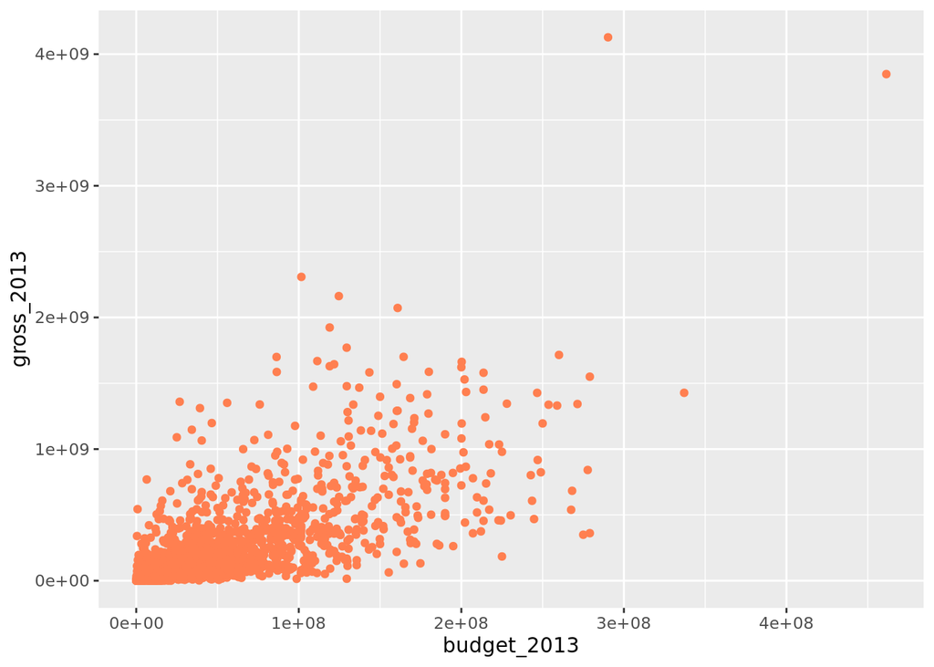

```r
ggplot(bechdel,
       aes(x = budget_2013, y = gross_2013)) +
  geom_point(color = "coral")
```

### Step 2 - Your turn

Add labels for the title and x and y axes.

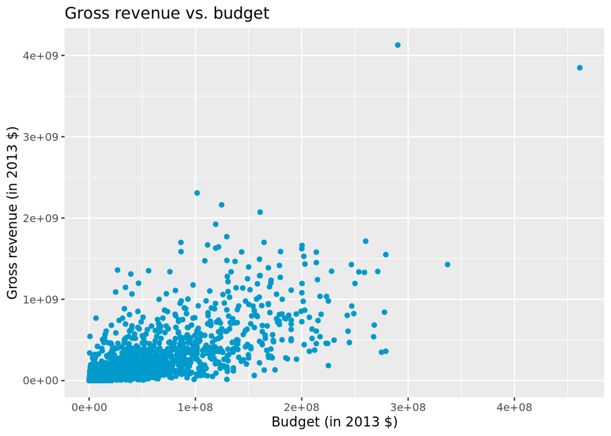

```r
ggplot(bechdel,
       aes(x = budget_2013, y = gross_2013))+
  geom_point(color = "deepskyblue3") +
  labs(
    x = "Budget (in 2013 $)",
    y = "Gross revenue (in 2013 $)",
    title = "Gross revenue vs. budget"
    )
```

### Step 3 - Your turn

An `aes`thetic is a visual property of one of the objects in your plot. Commonly used aesthetic options are:

- color
- fill
- shape
- size
- alpha (transparency)

Modify the plot below, so the `color` of the points is based on the variable `binary`.

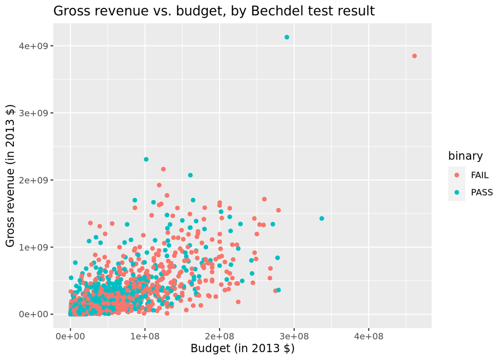

```r
ggplot(bechdel,
       aes(x = budget_2013, y = gross_2013, color = binary)) +
  geom_point() +
  labs(
    x = "Budget (in 2013 $)",
    y = "Gross revenue (in 2013 $)",
    title = "Gross revenue vs. budget, by Bechdel test result"
    )
```

### Step 4 - Your turn

Expand on your plot from the previous step to make the size of your points based on `roi`.

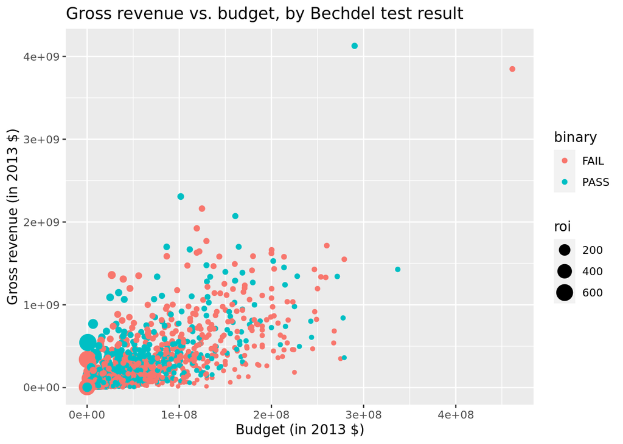

```r
ggplot(bechdel,
       aes(x = budget_2013, y = gross_2013,
           color = binary, size = roi)) +
  geom_point() +
  labs(
    x = "Budget (in 2013 $)",
    y = "Gross revenue (in 2013 $)",
    title = "Gross revenue vs. budget, by Bechdel test result"
    )
```

### Step 5 - Your turn

Expand on your plot from the previous step to make the transparency (`alpha`) of the points 0.5.

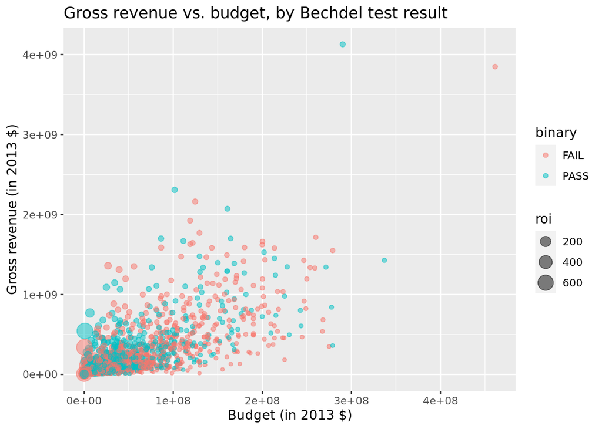

```r
ggplot(bechdel,
       aes(x = budget_2013, y = gross_2013,
           color = binary, size = roi)) +
  geom_point(alpha = 0.5) +
  labs(
    x = "Budget (in 2013 $)",
    y = "Gross revenue (in 2013 $)",
    title = "Gross revenue vs. budget, by Bechdel test result"
    )
```

### Step 6 - Your turn

Expand on your plot from the previous step by using `facet_wrap` to display the association between budget and gross for different values of `clean_test`.

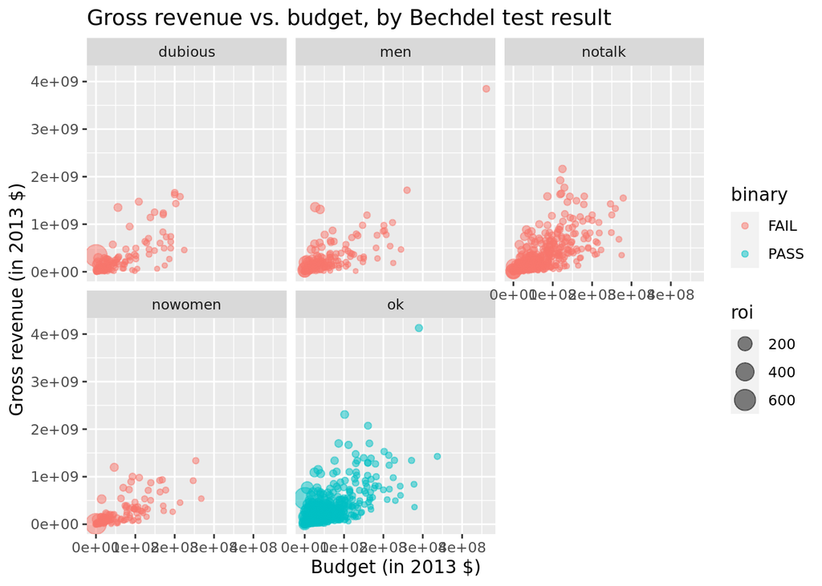

```r
ggplot(bechdel,
       aes(x = budget_2013, y = gross_2013,
           color = binary, size = roi)) +
  geom_point(alpha = 0.5) +
  facet_wrap(~clean_test) +
  labs(
    x = "Budget (in 2013 $)",
    y = "Gross revenue (in 2013 $)",
    title = "Gross revenue vs. budget, by Bechdel test result"
    )
```

### Step 7 - Demo

Improve your plot from the previous step by making the x and y scales more legible.

**Tip**

Make use of the [**scales**](https://scales.r-lib.org/) package, specifically the `scale_x_continuous()` and `scale_y_continuous()` functions.

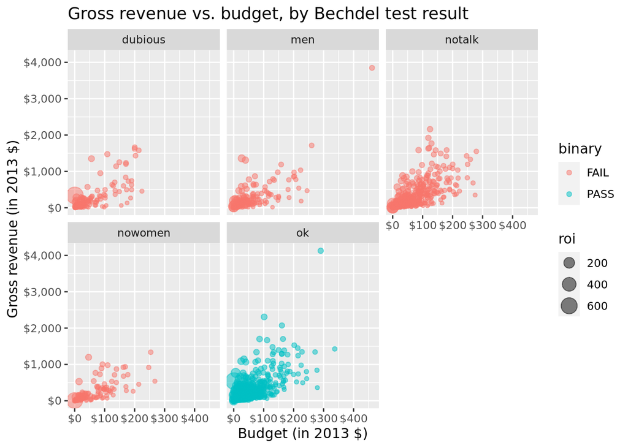

```r
ggplot(bechdel,
       aes(x = budget_2013, y = gross_2013,
           color = binary, size = roi)) +
  geom_point(alpha = 0.5) +
  facet_wrap(~clean_test) +
  scale_x_continuous(labels = label_dollar(scale = 1/1000000)) +
  scale_y_continuous(labels = label_dollar(scale = 1/1000000)) +
  labs(
    x = "Budget (in 2013 $)",
    y = "Gross revenue (in 2013 $)",
    title = "Gross revenue vs. budget, by Bechdel test result"
    )
```

### Step 8 - Your turn

Expand on your plot from the previous step by using `facet_grid` to display the association between budget and gross for different combinations of `clean_test` and `binary`. Comment on whether this was a useful update.

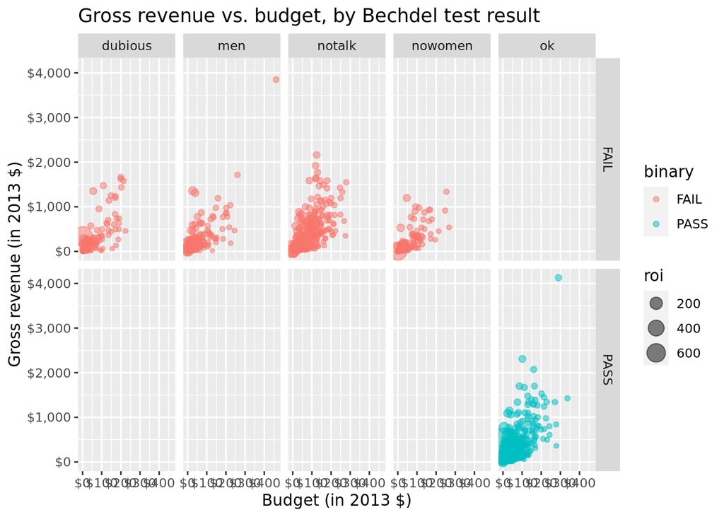

```r
ggplot(bechdel,
       aes(x = budget_2013, y = gross_2013,
           color = binary, size = roi)) +
  geom_point(alpha = 0.5) +
  facet_grid(binary~clean_test) +
  scale_x_continuous(labels = label_dollar(scale = 1/1000000)) +
  scale_y_continuous(labels = label_dollar(scale = 1/1000000)) +
  labs(
    x = "Budget (in 2013 $)",
    y = "Gross revenue (in 2013 $)",
    title = "Gross revenue vs. budget, by Bechdel test result"
    )
```

This was not a useful update as one of the levels of `clean_test` maps directly to one of the levels of `binary`.

### Step 9 - Demo

What other improvements could we make to this plot?

```r
# Answers may vary
```

### Render, commit, and push

1. If you made any changes since the last render, render again to get the final version of the AE.
2. Check the box next to each document in the Git tab (this is called “staging” the changes). Commit the changes you made using a simple and informative message.
3. Use the **green arrow** to push your changes to your repo on GitHub.
4. Check your repo on GitHub and see the updated files. Once your updated files are in your repo on GitHub, you’re good to go!

## Return-on-investment

Finally, let’s take a look at return-on-investment (ROI).

### Step 1 - Your turn

Create side-by-side box plots of `roi` by `clean_test` where the boxes are colored by `binary`.

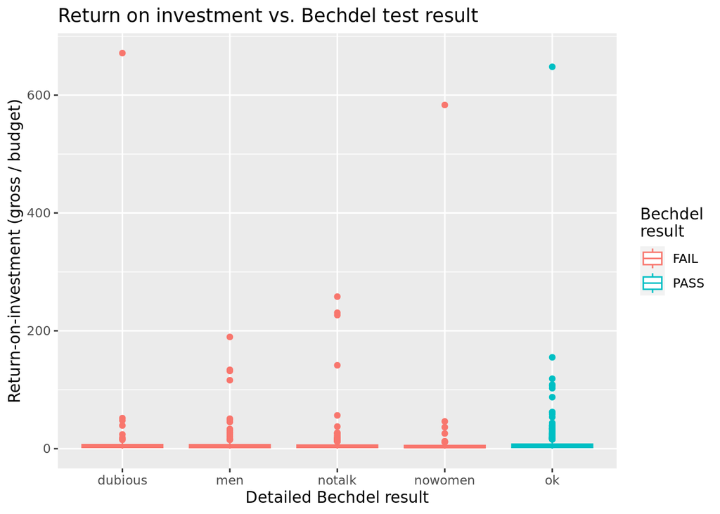

```r
ggplot(bechdel,
       aes(x = clean_test, y = roi, color = binary)) +
  geom_boxplot() +
  labs(
    title = "Return on investment vs. Bechdel test result",
    x = "Detailed Bechdel result",
    y = "Return-on-investment (gross / budget)",
    color = "Bechdel\nresult"
    )
```

What are those movies with *very* high returns on investment?

```r
bechdel |>
  filter(roi > 400) |>
  select(title, roi, budget_2013, gross_2013, year, clean_test)
```

```
# A tibble: 3 × 6
  title                     roi budget_2013 gross_2013  year clean_test
  <chr>                   <dbl>       <dbl>      <dbl> <dbl> <chr>
1 Paranormal Activity      671.      505595  339424558  2007 dubious
2 The Blair Witch Project  648.      839077  543776715  1999 ok
3 El Mariachi              583.       11622    6778946  1992 nowomen
```

### Step 2 - Demo

Expand on your plot from the previous step to zoom in on movies with `roi < ___` to get a better view of how the medians across the categories compare.

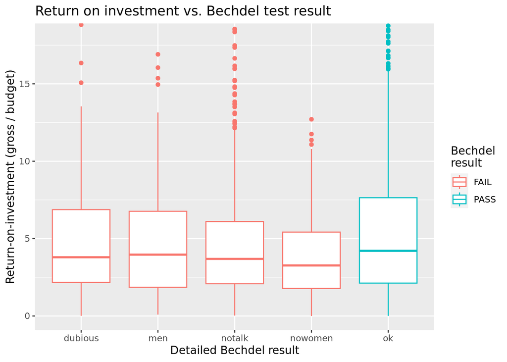

```r
ggplot(bechdel,
       aes(x = clean_test, y = roi, color = binary)) +
  geom_boxplot() +
  labs(
    title = "Return on investment vs. Bechdel test result",
    x = "Detailed Bechdel result",
    y = "Return-on-investment (gross / budget)",
    color = "Bechdel\nresult"
    ) +
  coord_cartesian(ylim = c(0, 18))
```

What does this plot say about return-on-investment on movies that pass the Bechdel test?